**Instructor copy.** Executed notebook with all results shown, including the "after your attempt" cells. Projector/offline fallback; learners should use the notebook itself.

# f0 · Jupyter and the thermodynamic potentials

**Learning question:** which energy does a sample minimise, and how do U, H, F and G follow from each other?

Used in: Day 1 W1–W3 (optional), Lesson 0, self-study step 00. Labels such as (W4), (D1), (Lesson 5) or Clinic D point to the printed one-day primers (Day 1 and Day 2 worksheets) and the detailed lessons of the classroom course in the repository. Working alone on the website, you only need the step numbers.

**How to use a notebook.** A notebook is a list of cells. Text cells (like this one) explain; code cells run Python. Click a code cell and press **Shift+Enter** to run it and move on. Run the cells from top to bottom. If something gets muddled, use *Kernel → Restart* (Colab: *Runtime → Restart session*) and run from the top again.

**What you will do here.** You will meet the four energies that thermodynamics uses: the internal energy U, the enthalpy H, the Helmholtz energy F and the Gibbs energy G. Each is calculated once in code, and then you calculate one yourself. At the end you will know why every later notebook compares Gibbs energies. No Python knowledge is assumed; each new piece of Python is explained the first time it appears.

The first code cell below prepares the notebook. You do not need to read it: it finds the course files, (in Colab) installs the course's package versions, and prints the versions it is using.

```python
# Setup: run this cell first. Locally it finds the course folder; in Colab it
# downloads the tested course release and the locked package versions.
# In Colab, the first run then restarts the session on purpose and Colab reports
# a crash: that is expected. Run this cell again, then the rest of the notebook.
RELEASE = "main"
import os, pathlib, subprocess, sys, time
ROOT = next((p for p in (pathlib.Path.cwd(), *pathlib.Path.cwd().parents)
             if (p / "pyproject.toml").is_file() and (p / "course").is_dir()), None)
if ROOT is None and "google.colab" in sys.modules:
    ROOT = pathlib.Path("/content/CalphadIntro")
    if not ROOT.is_dir():
        clone = ["git", "clone", "-q", "--depth", "1", "--branch", RELEASE,
                 "https://github.com/ukerzel/CalphadIntro.git", str(ROOT)]
        git = dict(os.environ, GIT_TERMINAL_PROMPT="0")
        if subprocess.run(clone, env=git, capture_output=True).returncode:
            raise SystemExit(f"Could not download course release {RELEASE}: check the internet "
                             "connection and run this cell again.")
    if not (ROOT / ".colab-ready").exists():
        if subprocess.run([sys.executable, "-m", "pip", "install", "-q", "-r",
                           str(ROOT / "notebooks" / "requirements-colab.txt")]).returncode:
            raise SystemExit("Installing the course packages failed; run this cell again.")
        (ROOT / ".colab-ready").touch()
        # Colab has already loaded its own numpy; a fresh session is needed to use the installed versions.
        print("Installed the course's package versions. Colab now restarts this session and"
              " reports a crash; that is expected. When it has reconnected, run this cell again"
              " (it will not install twice), then the rest of the notebook.", flush=True)
        time.sleep(3)
        os.kill(os.getpid(), 9)
if ROOT is None:
    raise SystemExit("Open this notebook from the course folder (poetry run jupyter lab) or in Colab.")
os.chdir(ROOT)
sys.path.insert(0, str(ROOT))
from notebooks.helpers import check, confirm, database, show_versions
show_versions(RELEASE)
```

```
Course release main · Python 3.12.14
  numpy       2.5.3
  scipy       1.18.1
  matplotlib  3.11.2
  xarray      2026.7.0
  pycalphad   0.11.2
```

```
True
```

**What the setup cell printed.** One line per package with its version number. If a line ends with "← locked run used …", your computer has a different version from the one the course was tested with; the notebook usually still works, but mention it if a later number disagrees.

The setup cell also made two small helper functions available, which you will see in almost every cell:

- `check(your_value, key)` (key: the name of the stored answer, in quotes) compares *your* answer with a stored answer without showing it. It prints "not attempted" while your value is still `None`, "✓ matches" when you are right, and a hint when you are not.
- `confirm(value, expected, "what", tol=...)` is used in the worked cells. It makes sure the code reproduces the number given in the lesson, to within the tolerance `tol`, and prints a ✓ line. If it ever stops with an error, the calculation and the lesson disagree; check the package versions first.

## 1. Numbers with units

Python does not know units, so we keep them in the variable names and comments. Pressure times volume is an energy: 1 Pa·m³ = 1 J.

**The physics.** The *internal energy* U is all the energy stored inside the sample: the motion of its atoms and the energy of the bonds between them. A sample also takes up space: at pressure p, making room for a volume V means pushing the surroundings back, which costs the work pV. The *enthalpy* adds that work to U:

$$H = U + pV.$$

Units: a pascal is a force per area, 1 Pa = 1 N/m², so Pa·m³ = N·m = J. For a solid or liquid at normal pressure the pV term is tiny compared with U (here 1 J out of 1000 J), which is why H and U are often almost equal for condensed matter.

**The Python.** `U = 999.0` is an *assignment*: it stores the number 999.0 under the name `U`. Writing `999.0` (with a decimal point) makes it a floating-point number. `*` multiplies, `+` adds. Everything after `#` on a line is a comment, ignored by Python; we use comments to note units. `print(f"...")` prints an *f-string*: the text between the quotes is printed as it is, except that `{pV:.0f}` is replaced by the value of `pV`, written with 0 digits after the decimal point (`.2f` would give two digits).

```python
U = 999.0        # internal energy, J
p = 100000.0     # pressure, Pa
V = 0.00001      # volume, m³
pV = p * V       # J  (Pa · m³ = N/m² · m³ = N·m = J)
H = U + pV       # enthalpy, J
print(f"pV = {pV:.0f} J, H = {H:.0f} J")   # the f-string fills in the values, rounded to whole J
confirm(H, 1000.0, "H = U + pV for the W1 worked state", tol=1e-9)   # stops with an error if H is not 1000 J
```

```
pV = 1 J, H = 1000 J
✓ H = U + pV for the W1 worked state reproduces the lesson value.
```

### Your turn (W1)

A sample receives 80 J of heat and does 10 J of work, so the work *on* the sample is −10 J. Find ΔU = q + w_on. Replace `None` with your value (in J) and run the cell.

**Sign convention.** This is the first law of thermodynamics: the internal energy changes by the heat q that flows *into* the sample plus the work w_on done *on* the sample. Energy that enters the sample counts as positive, energy that leaves counts as negative. When the sample pushes on its surroundings it *does* work, so the work done *on* it is negative.

You may type a number, or the arithmetic itself (for example `3 + 4`): Python evaluates it before `check` compares it. `None` is Python's word for "no value yet".

```python
delta_U = None  # J
check(delta_U, "f0_delta_u")   # compares with the stored answer; prints a hint if it differs
```

```
f0_delta_u: not attempted yet. Replace None with your value and run the cell again.
```

## 2. Entropy (W2)

Entropy S has units J/K. For a reversible heat transfer at constant absolute temperature, $\Delta S = q_{rev}/T$ (T in kelvin). A reversible 600 J input at 300 K gives ΔS = 2 J/K. Entropy is a state property, not a synonym for heat.

**What the symbols mean.** $q_{rev}$ is heat delivered *reversibly*, that is so slowly and gently that the sample stays in equilibrium the whole time. T must be the *absolute* temperature in kelvin (T/K = θ/°C + 273.15): dividing by a Celsius temperature would give nonsense, and at 0 °C would even divide by zero. Entropy measures how many microscopic arrangements are compatible with what we see from outside; adding heat lets the atoms explore more of them. The same amount of heat raises the entropy more at a low temperature than at a high one, which is why T is in the denominator. In Python, `/` divides.

```python
q_rev = 600.0      # reversible heat received, J
T_bath = 300.0     # K
delta_S = q_rev / T_bath   # J/K  (J divided by K)
print(f"ΔS = {delta_S:.0f} J/K")
confirm(delta_S, 2.0, "ΔS for the W2 worked transfer", tol=1e-12)
```

```
ΔS = 2 J/K
✓ ΔS for the W2 worked transfer reproduces the lesson value.
```

### Your turn (W2)

A reversible 900 J input at 300 K. What is ΔS (J/K)? What are the units of TS?

```python
delta_S_try = None  # J/K
check(delta_S_try, "f0_delta_s")
```

```
f0_delta_s: not attempted yet. Replace None with your value and run the cell again.
```

## 3. From U to G

$F = U - TS$ and $G = H - TS = F + pV$. Take the worked state from W1 at $T = 300$ K with $S = 10$ J/K.

**Why subtract TS?** F (the *Helmholtz energy*) and G (the *Gibbs energy*) are the energies that matter when the sample sits in surroundings at a fixed temperature. The product TS has units K · J/K = J, so it can be subtracted from an energy. At a high temperature the −TS term is large, so states with much entropy (much disorder) become favourable; at a low temperature the energy term U or H dominates. The second equality follows by substitution: $G = H - TS = (U + pV) - TS = (U - TS) + pV = F + pV$.

**The Python.** `T, S = 300.0, 10.0` assigns two values at once: the first goes to `T`, the second to `S`. The cell reuses `U`, `H` and `pV` from section 1, because a notebook remembers every variable from cells you have already run.

```python
T, S = 300.0, 10.0   # K, J/K
TS = T * S           # J
F = U - TS           # Helmholtz energy, J
G = H - TS           # Gibbs energy, J
print(f"TS = {TS:.0f} J, F = {F:.0f} J, G = {G:.0f} J, G − F = {G - F:.0f} J (= pV)")
confirm(G - F, pV, "G − F equals pV", tol=1e-9)   # G − F must be exactly the pV of section 1
```

```
TS = 3000 J, F = -2001 J, G = -2000 J, G − F = 1 J (= pV)
✓ G − F equals pV reproduces the lesson value.
```

### Your turn (W3, self-study step 00 "Try it")

The state U = 1498 J, p = 100000 Pa, V = 0.00002 m³, T = 300 K, S = 4 J/K. Compute H, F and G in J. Write the formulas, not just the numbers.

Tip: you can type each formula with the given numbers put in, for example `a * b + c` with numbers in place of the letters; Python does the arithmetic. The worked cell in section 3 shows which formula belongs to which energy.

```python
H_try = None  # J
F_try = None  # J
G_try = None  # J
check(H_try, "f0_try_h")
check(F_try, "f0_try_f")
check(G_try, "f0_try_g")
```

```
f0_try_h: not attempted yet. Replace None with your value and run the cell again.
f0_try_f: not attempted yet. Replace None with your value and run the cell again.
f0_try_g: not attempted yet. Replace None with your value and run the cell again.
```

## 4. Which energy is minimised?

For a simple bulk sample with fixed amounts of each component:

| Held fixed | The equilibrium state minimises |
| --- | --- |
| U and V (isolated) | it maximises S instead |
| T and V | F = U − TS |
| T and p | G = H − TS |
| T, p and the chemical potentials of the exchanged elements (open to a reservoir) | G − Σ μᵢnᵢ, summed over the exchanged elements only: a grand potential (step 04) |

Everything in this course is at fixed T and p, so we compare Gibbs energies.

**Why G at fixed T and p?** The basic law is the second law: the total entropy of the sample *plus* its surroundings cannot decrease. At constant pressure, heat q = ΔH flows from the surroundings into the sample when the sample's enthalpy changes by ΔH. The surroundings (a large bath at temperature T) lose that heat, so their entropy changes by −ΔH/T. The total change is

$$\Delta S_{total} = \Delta S - \frac{\Delta H}{T} = -\frac{\Delta H - T\Delta S}{T} = -\frac{\Delta G}{T}.$$

"Total entropy rises" is therefore the same statement as "the sample's G falls". A sample at fixed T and p keeps changing until G cannot go lower: that lowest-G state is the equilibrium. A CALPHAD program does exactly this search.

## 5. A first plot

How do the four energies of the "Try it" state change with temperature, if U, p, V and S stay fixed? (Only T changes in this sketch, to show which terms contain T; a real sample's U and S would change too.)

**New Python in this cell.**

- `import numpy as np` loads NumPy, the package for arrays of numbers, under the short name `np`; `import matplotlib.pyplot as plt` loads the plotting package as `plt`. Every notebook starts its calculations with lines like these.
- `np.linspace(0, 600, 61)` makes an *array* of 61 evenly spaced numbers from 0 to 600, both ends included: 0, 10, 20, …, 600 K.
- Arithmetic with an array acts on every element at once ("vectorised"): `U2 - temperatures * S2` gives an array of 61 values of F, one per temperature, without writing a loop.
- `np.full_like(temperatures, U2)` makes an array of the same length filled with the constant U2, so a constant can be plotted against T.
- `plt.subplots(...)` creates a figure `fig` with one set of axes `ax`; `figsize` is its size in inches. `ax.plot(x, y, style, label=...)` draws one line; the style string `"-"`, `":"`, `"--"` or `"-."` gives a solid, dotted, dashed or dash-dotted line. `ax.legend()` lists the labels, `plt.show()` displays the figure.

**What to look at.** U and H are horizontal lines, since neither contains T. F and G fall with slope −S. G stays above F by the constant pV (only 2 J here, so the two lines nearly overlap at this scale).

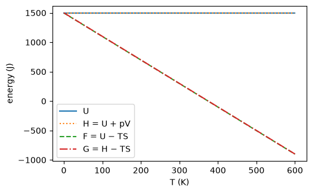

```python
import matplotlib.pyplot as plt
import numpy as np

U2, p2, V2, S2 = 1498.0, 100000.0, 0.00002, 4.0   # J, Pa, m³, J/K: the "Try it" state
temperatures = np.linspace(0, 600, 61)            # K, 61 values 0, 10, ..., 600
fig, ax = plt.subplots(figsize=(5.5, 3.4))        # one figure with one set of axes (size in inches)
ax.plot(temperatures, np.full_like(temperatures, U2), "-", label="U")   # constant: U has no T in it
ax.plot(temperatures, np.full_like(temperatures, U2 + p2 * V2), ":", label="H = U + pV")
ax.plot(temperatures, U2 - temperatures * S2, "--", label="F = U − TS")   # one value per temperature
ax.plot(temperatures, U2 + p2 * V2 - temperatures * S2, "-.", label="G = H − TS")
ax.set_xlabel("T (K)")
ax.set_ylabel("energy (J)")
ax.legend()      # box naming each line
plt.show()
```

The next cell prints the numbers behind three points of the plot. Its code is hidden in Colab (a "form" cell); double-click it to see the code. `for t in (0, 300, 600):` is a *loop*: the indented line below it runs three times, with `t` set to 0, then 300, then 600. `{t:3d}` prints the whole number t three characters wide, so the columns line up.

```python
#@title After your attempt: run to see the numbers behind the plot
for t in (0, 300, 600):   # t in K
    print(f"T = {t:3d} K: U = {U2:.0f}, H = {U2 + p2 * V2:.0f}, F = {U2 - t * S2:.0f}, G = {U2 + p2 * V2 - t * S2:.0f} J")
```

```
T =   0 K: U = 1498, H = 1500, F = 1498, G = 1500 J
T = 300 K: U = 1498, H = 1500, F = 298, G = 300 J
T = 600 K: U = 1498, H = 1500, F = -902, G = -900 J
```

**Limits.** These are invented definition exercises, not data for a material. Next: f1 · one component, two phases.